# Introduction and Motivation:

# Literature Review

## Children and Careers: How Family Size Affects Parents’ Labor Market Outcomes in the Long Run

- **Author:** Sara Cools, Simen Markussen, Marte Strom
- **[Link to article](https://pmc.ncbi.nlm.nih.gov/articles/PMC5624987/)**

The correlation between family size and the workforce, mainly weekly hours worked, has received considerable focus. Cools et al. (2017) use instrumental variables to analyze this and demonstrate that family size strongly and negatively affects mothers’ weekly working hours while fathers’ hours remain primarily unchanged. In essence, they argue that each additional child decreases mothers’ labor supply by, on average, 3-5 hours a week, with more pronounced effects during the early years following childbirth and enduring impacts in the scenario of highly educated women. As described, the study illustrates Becker’s well-known economic concepts, a posteriori validation of the econometric assumptions of the Beckerian household model, and a quantity-quality trade-off, which states that an increase in market work necessitated in response to increased childcare duties. Additionally, robust gaps in gender differences in the labor supply perpetuate the maternal employment paradigm, which positions women as principal caregivers. These findings suggest an urgency for more attention to subsidized child care, flexible work hours, active father involvement, and a reduction in the detrimental effects on women’s work hours. The study illustrates the implications of family size on parental participation in the labor market alongside the need for policies on gender inequality in the labor market.

## Gender Inequality, Work Hours, and the Future of Work

- **Authors:** Ariane Hegewisch, M.Phil., and Valerie Lacarte, Ph.D.
- **[Link to report](https://iwpr.org/wp-content/uploads/2020/07/C486_FOW-Work-Hours-Report.pdf)**

The Institute for Women’s Policy Research in 2020 stipulated that there is an unequal allocation of work opportunities to men and women, which in one way or another influences the number of hours each gender is required to work. Women, in most cases, do not work as many hours as men in a week because of an amalgamation of caregiving duties, social norms, and a lack of accepted domestic help, which women have to shoulder alongside their primary work. Women are more likely than men to work shorter hours, not because they want to, but because they are trying to juggle caregiving responsibilities, which decreases their earnings. But it seems men actively take on more full-time and overtime positions that offer set hours. Thus, their earnings increase substantially compared to women's because established practices confirm that subordinate social classes have to work hard to earn good money, and this is especially true in low-paying jobs within the service sector where women are hopelessly trapped.

## Immigration and work schedules: Theory and evidence

- **Authors:** Timothy N. Bond, Osea Giuntella, Jakub Lonsky
- **[Link to report](https://www.sciencedirect.com/science/article/pii/S0014292122002380)**

Regardless of how their weekly employment compares to that of native workers, immigrants are known to work more hours per week, especially during the night. In a study conducted by Bond et al. (2023), it was established that immigrants ‘disproportionately’ fill positions featuring longer or irregular hours because of economic necessity, lower disutility costs, and lack of alternative employment options. Consequently, native workers in regions with higher inflows of immigrant workers tend to receive disproportionate daytime shifts. The reasoning is that immigration to an area causes a decline in compensating differentials for night work. Immigrants tend to accept lower wages and work night shifts, which are undesirable. The study shows that a 10 percentage point increase in the share of immigrants in the workforce decreases the probability of natives working night shifts by 0.8 percentage points and increases wages for daytime shifts. The findings highlight that citizenship status is crucial in allocating work schedules, especially non-citizens, who are overrepresented and fill lower-amenity, extended, or irregular-hours jobs. Even as natives enjoy flexible access to standard work schedules, immigrants are compelled to work longer hours in low-paying, labor-intensive, and monotonous job sectors.

## Degrees to Desk: The Link Between Education and Workweek Length and Gender-based Differences

- **Authors:** Chloe Smith
- **Link to article**

There is a pattern with the level of education and the number of hours worked weekly. Highly educated people tend to work for more hours a week. As per the analysis by Chloe Smith, people with a college degree are likelier to work for a full-time forty-hour work week, while people who do not hold a high school diploma tend to work part-time and spend thirty hours a week at work. The study also reports that holders of professional degrees like law, medicine, and engineering are likelier to work more than forty hours a week. About 40.85% of these people are known to work overtime. This fact, alongside the study, points towards the higher employment rates and better job security that come with advanced education, resulting in high-time commitment positions. The study mentions the correlation between education level and workweek balance; one highlights that education access changes employment patterns and workloads.

## Low-income workers experience—by far—the most earnings and work hours instability

- **Authors:** Lauren Bauer, Chloe East
- **[Link to article](https://www.brookings.edu/articles/low-income-workers-experience-by-far-the-most-earnings-and-work-hours-instability/)**

Income level and weekly work hours have a unique, intricate relationship in defining their complexities. Brookings shows that the lowest-earning workers have the deepest wage and hourly instability as they suffer from unreliable scheduling and ever-changing weekly hours. On the one hand, lower-wage workers tend to work part-time to earn a little extra money. Still, due to employer wage determination policies, there is a lack of consistency due to part-time employment structure, limited job security, and market-segmented employment. On the other hand, higher-income workers tend to receive more excellent income stabilization over time because they have more consistent and predictable schedules – even though many professionals in salaried positions also “volunteer” to work much longer hours due to career-related demands and expectations. Adding to this, Bick, Fuchs-Schündeln, and Lagakos (2018) suggest that in lower-income countries, people generally put in more hours per week than in richer ones. This tends to switch within high-income countries, where lower-wage workers are in and out of irregular employment bound by changing hours. Still, higher wage earners are bound to longer hours due to professional responsibilities.

# **Data and Descriptive stats**

```python
# import necessary package
import os
import pandas as pd
import numpy as np
import matplotlib.pyplot as plt
import statsmodels.formula.api as smf
import seaborn as sns
# pd.set_option('display.float_format', lambda x: f'{x:g}')

pd.set_option('display.float_format', lambda x: f'{x:f}')
df = pd.read_csv('final_project_data.csv')
df = df[["UHRSWORK", "OCC", "SEX", "STATEICP","CITIZEN","FAMSIZE"]]
df.describe()
```

|  | UHRSWORK | OCC | SEX | STATEICP | CITIZEN | FAMSIZE |
| --- | --- | --- | --- | --- | --- | --- |
| count | 3405809.000000 | 3405809.000000 | 3405809.000000 | 3405809.000000 | 3405809.000000 | 3405809.000000 |
| mean | 19.463403 | 2438.405749 | 1.509099 | 41.390026 | 0.314384 | 2.995439 |
| std | 21.075620 | 2909.883605 | 0.499917 | 20.876460 | 0.825751 | 1.722640 |
| min | 0.000000 | 0.000000 | 1.000000 | 1.000000 | 0.000000 | 1.000000 |
| 25% | 0.000000 | 0.000000 | 1.000000 | 23.000000 | 0.000000 | 2.000000 |
| 50% | 8.000000 | 845.000000 | 2.000000 | 44.000000 | 0.000000 | 3.000000 |
| 75% | 40.000000 | 4600.000000 | 2.000000 | 54.000000 | 0.000000 | 4.000000 |
| max | 99.000000 | 9920.000000 | 2.000000 | 98.000000 | 3.000000 | 20.000000 |

### Description of the original data

|  | Name | Type | Description |
| --- | --- | --- | --- |
| 0 | UHRSWORK | int 64 | UHRSWORK reports the number of hours per week that the respondent usually worked, if the person worked during the previous year. |
| 1 | OCC | int 64 | OCC reports the person's primary occupation, value ranges from 0000 to 9999, each number represents a spefic occupation. |
| 2 | SEX | int 64 | SEX reports whether the person was male or female. 1: Male 2: Female 9: Missing |
| 3 | STATEICP | int 64 | STATEICP identifies the state in which the housing unit was located, using the coding scheme developed by the Inter-University Consortium for Political and Social Research (ICPSR).Range from 01 to 99,… |
| 4 | CITIZEN | int 64 | CITIZEN reports the citizenship status of respondents. 0: Normal citizen 1: Born by US parents abroad 2: Naturalized 3: None citizen 4: None citizen with first letter 5: Foreign born without report 8:… |
| 5 | FAMSIZE | int 64 | FAMSIZE counts the number of own family members residing with each individual. |

### **Data cleaning and modify**

```python
# Exclude invalid data
df = df[~df['STATEICP'].isin([83, 96, 97, 99])]
df = df[df['SEX'] != 9]
df = df[~df['CITIZEN'].isin([0, 8, 9, 5])]
df = df[~df['OCC'].isin([0, 9920])]
df = df[(df["UHRSWORK"] != 0)]
```

```python
# Rename some data
df.rename(columns={
    "UHRSWORK": "Hours_Worked_Per_Week",
    "OCC": "Occupation",
    "SEX": "Gender",
    "CITIZEN": "Citizenship",
    "FAMSIZE": "Family_Size"
}, inplace=True)
#For gender, we would make it a dummi variable of been female or not
df["Gender"] = df["Gender"].apply(lambda x: 1 if x == 2 else 0)
#For State we, first convert large states into different regions
state_to_region = {
    # Northeast
    1: "Northeast", 2: "Northeast", 3: "Northeast", 4: "Northeast", 5: "Northeast", 6: "Northeast",
    11: "Northeast", 12: "Northeast", 13: "Northeast", 14: "Northeast",
    # Midwest
    21: "Midwest", 22: "Midwest", 23: "Midwest", 24: "Midwest", 25: "Midwest",
    31: "Midwest", 32: "Midwest", 33: "Midwest", 34: "Midwest", 35: "Midwest", 36: "Midwest", 37: "Midwest",
    # South
    41: "South", 42: "South", 43: "South", 44: "South", 45: "South", 46: "South", 47: "South", 48: "South",
    49: "South", 51: "South", 52: "South", 53: "South", 54: "South", 56: "South",
    # West
    61: "West", 62: "West", 63: "West", 64: "West", 65: "West", 66: "West", 67: "West", 68: "West",
    71: "West", 72: "West", 73: "West", 81: "West", 82: "West"
}
# Map STATEICP to regions
df['Region'] = df['STATEICP'].map(state_to_region)
# Define a mapping of OCC codes to five broad categories
occ_to_category = {
    # Management, Business, Science, and Arts Occupations
    **dict.fromkeys(range(10, 2000), "Management, Business, Science, and Arts"),

    # Service Occupations
    **dict.fromkeys(range(3600, 4700), "Service"),

    # Sales and Office Occupations
    **dict.fromkeys(range(4700, 6000), "Sales and Office"),

    # Natural Resources, Construction, and Maintenance Occupations
    **dict.fromkeys(range(6000, 7700), "Natural Resources, Construction, and Maintenance"),

    # Production, Transportation, and Material Moving Occupations
    **dict.fromkeys(range(7700, 9900), "Production, Transportation,and Material Moving"),

    # Not Applicable or Unemployed
    **dict.fromkeys([0, 9920], "Not Applicable/Unemployed")
}

# Map OCC codes to categories
df['Occupation'] = df['Occupation'].map(occ_to_category)
```

### Here is the table after our modify of data

[output not shown]

### **Create Dummi variables for qualitative data**

```python
# Do dummi for region
region_dummies = pd.get_dummies(df['Region'], prefix='Region', drop_first=True)
df = pd.concat([df, region_dummies], axis=1)


# Do dummi for occupation
occupation_dummies = pd.get_dummies(df['Occupation'], prefix='Occupation', drop_first=True)
df = pd.concat([df, occupation_dummies], axis=1)
df = pd.concat([df], axis=1)

change = [col.replace(" ", "_").replace(",", "").replace("-", "_") for col in occupation_dummies.columns]
occupation_dummies.columns = change
df = df.drop(columns=change, errors='ignore')
df = pd.concat([df, occupation_dummies], axis=1)
```

## **Plots**

```
     STATEICP    State
17         41  Alabama
167        41  Alabama
238        41  Alabama
610        41  Alabama
634        41  Alabama
```

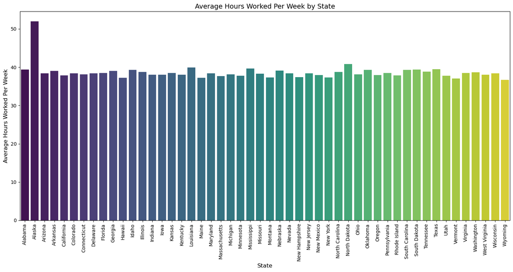

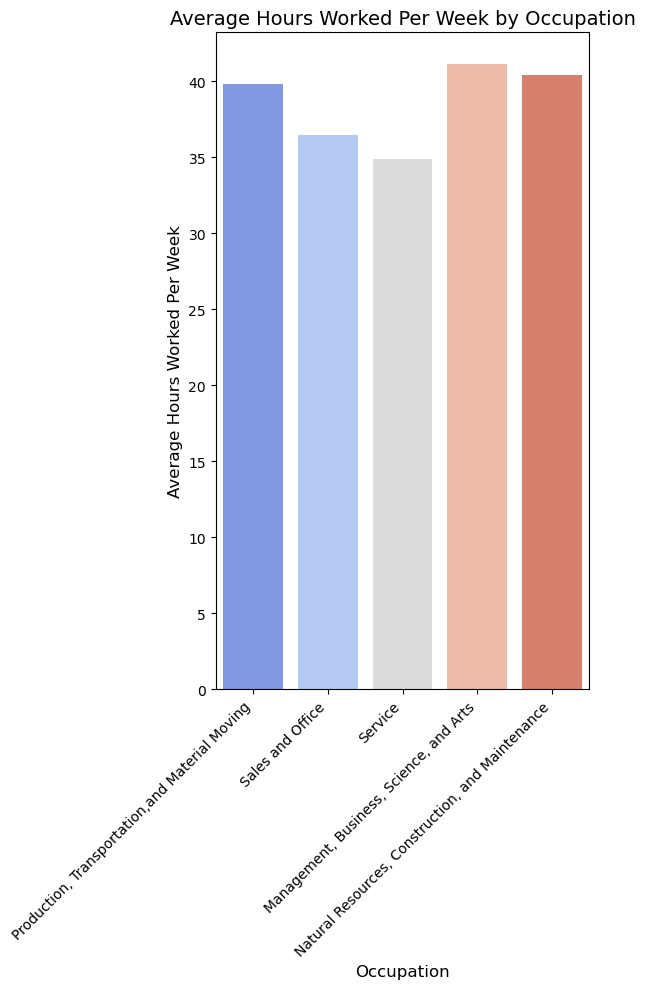

```python
state_labels = {
    1: "Connecticut", 2: "Maine", 3: "Massachusetts", 4: "New Hampshire", 5: "Rhode Island", 6: "Vermont",
    11: "Delaware", 12: "New Jersey", 13: "New York", 14: "Pennsylvania",
    21: "Illinois", 22: "Indiana", 23: "Michigan", 24: "Ohio", 25: "Wisconsin",
    31: "Iowa", 32: "Kansas", 33: "Minnesota", 34: "Missouri", 35: "Nebraska", 36: "North Dakota", 37: "South Dakota",
    40: "Virginia", 41: "Alabama", 42: "Arkansas", 43: "Florida", 44: "Georgia", 45: "Louisiana", 46: "Mississippi",
    47: "North Carolina", 48: "South Carolina", 49: "Texas", 51: "Kentucky", 52: "Maryland", 53: "Oklahoma",
    54: "Tennessee", 56: "West Virginia", 61: "Arizona", 62: "Colorado", 63: "Idaho", 64: "Montana", 65: "Nevada",
    66: "New Mexico", 67: "Utah", 68: "Wyoming", 71: "California", 72: "Oregon", 73: "Washington", 81: "Alaska", 82: "Hawaii"
}
df['State'] = df['STATEICP'].map(state_labels)
print(df[['STATEICP', 'State']].head())

# Bar plot for Hours Worked Per Week by State
plt.figure(figsize=(15, 8))
sns.barplot(x='State', y='Hours_Worked_Per_Week', data=df, ci=None, palette='viridis')
plt.title('Average Hours Worked Per Week by State', fontsize=14)
plt.xlabel('State', fontsize=12)
plt.ylabel('Average Hours Worked Per Week', fontsize=12)
plt.xticks(rotation=90)
plt.tight_layout()
plt.show()

# Bar plot for Hours Worked Per Week by Occupation
plt.figure(figsize=(6, 10))
sns.barplot(x='Occupation', y='Hours_Worked_Per_Week', data=df, ci=None, palette='coolwarm')
plt.title('Average Hours Worked Per Week by Occupation', fontsize=14)
plt.xlabel('Occupation', fontsize=12)
plt.ylabel('Average Hours Worked Per Week', fontsize=12)
plt.xticks(rotation=45, ha='right')
plt.tight_layout()
plt.show()
```

From the 2 plots, we can see that occupation can have difference in working hours. For example, the Service-related occupation works less on average more than 5 hours compare to Management, Bussiness,Science, and Arts. Which mean this data is worth us to include in the regression. However, we can see that in most cases(except Alaska), states do not have significant effect on working hours. To enlarge the difference, we tried divided the states into regions.

# Regression model and results (preliminary for proposal just the intuition of the betas and the equation)

$$y=\beta_0 + \beta_1*x_1 + \beta_2*x_2 + \beta_3*x_3 + ... +\beta_n*x_n + \mu$$

```python
# regression=smf.ols(formula = "Hours_Worked_Per_Week ~ Citizenship+Gender+Education_Level+Income_Wage+Family_Size",data= df).fit()
regression_region = smf.ols(
    formula="Hours_Worked_Per_Week ~ Citizenship + Gender + Family_Size + " + " + ".join(region_dummies.columns),
    data=df
).fit()

display(regression_region.summary())
```

OLS Regression Results

| Dep. Variable: | Hours_Worked_Per_Week | R-squared: | 0.030 |
| --- | --- | --- | --- |
| Model: | OLS | Adj. R-squared: | 0.030 |
| Method: | Least Squares | F-statistic: | 1515. |
| Date: | Mon, 21 Apr 2025 | Prob (F-statistic): | 0.00 |
| Time: | 20:12:20 | Log-Likelihood: | -1.1368e+06 |
| No. Observations: | 289223 | AIC: | 2.274e+06 |
| Df Residuals: | 289216 | BIC: | 2.274e+06 |
| Df Model: | 6 |  |  |
| Covariance Type: | nonrobust |  |  |

|  | coef | std err | t | P>\|t\| | [0.025 | 0.975] |
| --- | --- | --- | --- | --- | --- | --- |
| Intercept | 41.4385 | 0.118 | 350.555 | 0.000 | 41.207 | 41.670 |
| Region_Northeast[T.True] | -0.4851 | 0.081 | -5.957 | 0.000 | -0.645 | -0.326 |
| Region_South[T.True] | 0.5548 | 0.075 | 7.349 | 0.000 | 0.407 | 0.703 |
| Region_West[T.True] | -0.3078 | 0.075 | -4.098 | 0.000 | -0.455 | -0.161 |
| Citizenship | -0.4600 | 0.038 | -12.042 | 0.000 | -0.535 | -0.385 |
| Gender | -4.2839 | 0.046 | -93.012 | 0.000 | -4.374 | -4.194 |
| Family_Size | -0.0034 | 0.013 | -0.263 | 0.792 | -0.029 | 0.022 |

| Omnibus: | 19964.070 | Durbin-Watson: | 1.874 |
| --- | --- | --- | --- |
| Prob(Omnibus): | 0.000 | Jarque-Bera (JB): | 103981.694 |
| Skew: | -0.019 | Prob(JB): | 0.00 |
| Kurtosis: | 5.937 | Cond. No. | 28.3 |

Notes:  
[1] Standard Errors assume that the covariance matrix of the errors is correctly specified.

```python
regression_occupation = smf.ols(
     formula="Hours_Worked_Per_Week ~ Citizenship + Gender  + Family_Size + " + " + ".join(occupation_dummies.columns),
     data=df
 ).fit()
display(regression_occupation.summary())
#Cancel the comments above once the occupation column names are washed properly
```

OLS Regression Results

| Dep. Variable: | Hours_Worked_Per_Week | R-squared: | 0.047 |
| --- | --- | --- | --- |
| Model: | OLS | Adj. R-squared: | 0.047 |
| Method: | Least Squares | F-statistic: | 2017. |
| Date: | Mon, 21 Apr 2025 | Prob (F-statistic): | 0.00 |
| Time: | 20:12:21 | Log-Likelihood: | -1.1344e+06 |
| No. Observations: | 289223 | AIC: | 2.269e+06 |
| Df Residuals: | 289215 | BIC: | 2.269e+06 |
| Df Model: | 7 |  |  |
| Covariance Type: | nonrobust |  |  |

|  | coef | std err | t | P>\|t\| | [0.025 | 0.975] |
| --- | --- | --- | --- | --- | --- | --- |
| Intercept | 41.9048 | 0.104 | 402.763 | 0.000 | 41.701 | 42.109 |
| Occupation_Natural_Resources_Construction_and_Maintenance[T.True] | -0.6482 | 0.084 | -7.760 | 0.000 | -0.812 | -0.484 |
| Occupation_Production_Transportationand_Material_Moving[T.True] | -0.4244 | 0.072 | -5.931 | 0.000 | -0.565 | -0.284 |
| Occupation_Sales_and_Office[T.True] | -2.7303 | 0.069 | -39.642 | 0.000 | -2.865 | -2.595 |
| Occupation_Service[T.True] | -4.2252 | 0.064 | -66.538 | 0.000 | -4.350 | -4.101 |
| Citizenship | -0.2852 | 0.039 | -7.407 | 0.000 | -0.361 | -0.210 |
| Gender | -3.6958 | 0.048 | -76.690 | 0.000 | -3.790 | -3.601 |
| Family_Size | 0.0479 | 0.013 | 3.733 | 0.000 | 0.023 | 0.073 |

| Omnibus: | 20936.801 | Durbin-Watson: | 1.874 |
| --- | --- | --- | --- |
| Prob(Omnibus): | 0.000 | Jarque-Bera (JB): | 114747.039 |
| Skew: | 0.023 | Prob(JB): | 0.00 |
| Kurtosis: | 6.085 | Cond. No. | 21.8 |

Notes:  
[1] Standard Errors assume that the covariance matrix of the errors is correctly specified.

```python
regressors = ['Citizenship', 'Gender', 'Family_Size'] + region_dummies.columns.tolist() + occupation_dummies.columns.tolist()
formula_full = "Hours_Worked_Per_Week ~ " + " + ".join(regressors)

regression_full = smf.ols(formula=formula_full, data=df).fit()
display(regression_full.summary())
```

OLS Regression Results

| Dep. Variable: | Hours_Worked_Per_Week | R-squared: | 0.048 |
| --- | --- | --- | --- |
| Model: | OLS | Adj. R-squared: | 0.048 |
| Method: | Least Squares | F-statistic: | 1448. |
| Date: | Mon, 21 Apr 2025 | Prob (F-statistic): | 0.00 |
| Time: | 20:12:21 | Log-Likelihood: | -1.1342e+06 |
| No. Observations: | 289223 | AIC: | 2.268e+06 |
| Df Residuals: | 289212 | BIC: | 2.269e+06 |
| Df Model: | 10 |  |  |
| Covariance Type: | nonrobust |  |  |

|  | coef | std err | t | P>\|t\| | [0.025 | 0.975] |
| --- | --- | --- | --- | --- | --- | --- |
| Intercept | 41.7917 | 0.118 | 353.739 | 0.000 | 41.560 | 42.023 |
| Region_Northeast[T.True] | -0.3108 | 0.081 | -3.847 | 0.000 | -0.469 | -0.152 |
| Region_South[T.True] | 0.7058 | 0.075 | 9.420 | 0.000 | 0.559 | 0.853 |
| Region_West[T.True] | -0.1575 | 0.075 | -2.114 | 0.035 | -0.304 | -0.011 |
| Occupation_Natural_Resources_Construction_and_Maintenance[T.True] | -0.7197 | 0.084 | -8.604 | 0.000 | -0.884 | -0.556 |
| Occupation_Production_Transportationand_Material_Moving[T.True] | -0.4411 | 0.072 | -6.166 | 0.000 | -0.581 | -0.301 |
| Occupation_Sales_and_Office[T.True] | -2.7587 | 0.069 | -40.063 | 0.000 | -2.894 | -2.624 |
| Occupation_Service[T.True] | -4.2251 | 0.063 | -66.551 | 0.000 | -4.350 | -4.101 |
| Citizenship | -0.2871 | 0.038 | -7.459 | 0.000 | -0.363 | -0.212 |
| Gender | -3.6929 | 0.048 | -76.672 | 0.000 | -3.787 | -3.598 |
| Family_Size | 0.0532 | 0.013 | 4.147 | 0.000 | 0.028 | 0.078 |

| Omnibus: | 20994.861 | Durbin-Watson: | 1.877 |
| --- | --- | --- | --- |
| Prob(Omnibus): | 0.000 | Jarque-Bera (JB): | 115395.124 |
| Skew: | 0.024 | Prob(JB): | 0.00 |
| Kurtosis: | 6.094 | Cond. No. | 28.5 |

Notes:  
[1] Standard Errors assume that the covariance matrix of the errors is correctly specified.

The reason why we chose the following variables for the simple regression model is due to the fact we believe that the variables listed above are curcial and are heavily corelated to the dependent variable (the working hour per week) in reality.

1. Citizenship

Citizenship status is a key socioeconomic indicator that can affect the types of jobs individuals hold and the conditions under which they work. Non-citizens may face fewer job protections and more economic pressure, leading them to accept longer or less flexible work hours. Including this variable allows us to assess how legal and structural factors tied to immigration status shape labor patterns.

2. Gender

Gender is one of the most widely studied dimensions in labor economics, and prior research consistently shows significant differences in work hours between men and women. These disparities often stem from caregiving responsibilities, occupational segregation, and societal expectations. Including gender helps us quantify how these patterns show up in weekly hours worked.

3. Family Size

Family size is a proxy for household responsibilities and financial obligations. Larger families may push individuals to work more hours to meet household needs, although the effect could vary depending on access to childcare, social support, or cultural norms. We include this variable to test whether people with more dependents actually work longer hours.

4. Region

Geographic region affects employment opportunities, job types, and cost of living. For example, labor markets in the South differ from those in the Northeast in terms of job structure, wages, and hours expectations. By including region, we can account for broad structural differences across U.S. labor markets that may influence how much people work.

5. Occupation

Occupation captures the type of work someone does, which directly influences work hours. Some professions (like healthcare, construction, or management) typically demand longer schedules, overtime, or irregular hours. Including occupation helps us control for job-specific effects on work intensity and better isolate the impact of other variables like gender or citizenship.

# Results

We estimated an OLS regression model to examine how weekly hours worked relate to demographic and structural factors, including citizenship, gender, family size, region, and occupation. The dependent variable is Hours_Worked_Per_Week.

```python
!jupyter nbconvert --to html '/content/drive/MyDrive/Shared/Project/Final Project Template.ipynb'
```

[output not shown]

[output cut: 135 more lines]

[output not shown]

[output not shown]